# 2_259195_Piotr_Jasiński

## LABORATORIUM 2 - KLASYFIKACJA LINIOWA

### 2.1 Porównanie sklearn i własnej implementacji klasyfikatora na syntetycznych zbiorach

```python
import numpy as np
from sklearn.linear_model import RidgeClassifier
from sklearn.metrics import accuracy_score
from sklearn.datasets import make_classification
from sklearn.datasets import make_moons
import matplotlib.pyplot as plt
from sklearn.metrics import confusion_matrix
from sklearn.metrics import auc, roc_curve
import time
```

#### Funkcja generująca dane do klasyfikacji:

```python
from sklearn.model_selection import train_test_split


def generate_data(n_samples, n_features, random_state):
    X, y = make_classification(
        n_samples=n_samples,
        n_features=n_features,
        n_informative=n_features,
        n_redundant=0,
        n_clusters_per_class=1,
        random_state=random_state
    )
    y = 2 * y - 1 ## przekształcenie etykiet na {-1, 1}

    return X, y

def generate_moons(n_samples, random_state):
    X_moons, y_moons = make_moons(n_samples=n_samples, noise=0.1, random_state=random_state)
    y_moons = 2 * y_moons - 1

    return X_moons, y_moons
```

#### Funkcja licząca metryki wynikowe:

```python
from sklearn.metrics import ConfusionMatrixDisplay
import pandas as pd

def compute_metrics(y_test, y_pred, classifier_name, dataset_name, labels):
    # macierz pomyłek
    cm = confusion_matrix(y_test, y_pred)
    print(cm)
    tn, fp, fn, tp = cm.ravel()

    # czułość i swoistość
    sensitivity = tp / (tp + fn) if (tp + fn) > 0 else 0
    specificity = tn / (tn + fp) if (tn + fp) > 0 else 0

    #skuteczność
    accuracy = accuracy_score(y_test, y_pred)

    # krzywa roc i auc
    fpr, tpr, thresholds  = roc_curve(y_test, y_pred)
    roc_auc = auc(fpr, tpr)

    print(f"{classifier_name} na {dataset_name}:")
    print(f"Skuteczność: {accuracy*100:.4f}%")
    print(f"Czułość (Recall): {sensitivity*100:.4f}%")
    print(f"Swoistość: {specificity*100:.4f}%")
    print(f"ROC AUC: {roc_auc:.4f}")

    display = ConfusionMatrixDisplay(confusion_matrix=cm, display_labels=labels)
    display.plot(cmap="Greens")
    plt.title("Macierz pomyłek")
    plt.show

    plt.figure(figsize=(8, 6))
    plt.plot(fpr, tpr, color='blue', label=f'ROC Curve (AUC = {roc_auc:.2f})')
    plt.xlabel('Współczynnik FP (1 - Specificity)')
    plt.ylabel('współczynnik TP (Sensitivity)')
    plt.title('Krzywa ROC')
    plt.legend(loc='lower right')
    plt.grid()
    plt.show()
```

#### Funkcja analityczna wraz z funkcją predict:

```python
def analytical_clf_fit(X, y, alpha=0.001):
    y = np.array(y)
    n_samples, n_features = X.shape

    X_bias = np.hstack([X, np.ones((n_samples, 1))])

    I = np.eye(n_features + 1)
    I[-1, -1] = 0  # Brak regularyzacji dla biasu

    w = np.linalg.inv(X_bias.T @ X_bias + alpha * I) @ X_bias.T @ y

    return w

def analytical_clf_predict(X, solution, labels):
    X = np.hstack([X, np.ones((X.shape[0], 1))])  # Dodaj kolumnę jedynki
    predictions = X @ solution
    signs = np.sign(predictions).astype(int)

    mapped_predictions = np.where(signs == -1, labels[0], labels[1])
    return mapped_predictions
```

#### Funkcja wykorzystująca gotową klasyfikację z biblioteki *sklearn*:

```python
def sklearn_ridge_clf(X_train, y_train, X_test, alpha=0.001):
    clf = RidgeClassifier(alpha=alpha)

    clf.fit(X_train, y_train)
    predictions = clf.predict(X_test)

    return predictions
```

#### Funkcja porównująca metody dla danego zbioru danych:

```python
def evaluate_dataset(X, y, name):
    X_train, X_test, y_train, y_test = train_test_split(X, y, test_size=0.2, random_state=95)

    start = time.time()
    for _ in range(100):
        w = analytical_clf_fit(X_train, y_train)
        predictions1 = analytical_clf_predict(X_test, w, [-1, 1])
    end = time.time()
    print(f"Czas wykonania metody analitycznej: {end - start}s.")
    compute_metrics(y_test, predictions1, "Analityczna", name, [-1, 1])

    plt.figure(figsize=(8,6))
    plt.scatter(X_train[:,0], X_train[:,1], c=y_train, edgecolors='k')
    plt.xlabel("Feature 1")
    plt.ylabel("Feature 2")
    plt.grid(alpha=0.5)

    h = 0.01
    x_min, x_max = X_train[:, 0].min() - 0.2, X_train[:, 0].max() + 1
    y_min, y_max = X_train[:, 1].min() - 0.2, X_train[:, 1].max() + 1
    xx, yy = np.meshgrid(np.arange(x_min, x_max, h),
                        np.arange(y_min, y_max, h))
    grid_points = np.c_[xx.ravel(), yy.ravel()]
    Z = analytical_clf_predict(grid_points, w, [-1, 1])
    Z = Z.reshape(xx.shape)

    plt.contourf(xx, yy, Z, alpha=0.3, cmap=plt.cm.coolwarm)

    plt.scatter(X_train[:, 0], X_train[:, 1], c=y_train, edgecolors='k', cmap=plt.cm.coolwarm)
    plt.xlabel("Feature 1")
    plt.ylabel("Feature 2")
    plt.grid(alpha=0.5)

    x_vals = np.linspace(X_train[:, 0].min() - 0.2, X_train[:, 0].max() + 0.2, 100)
    w1, w2, bias = w
    y_vals = -(bias + w1 * x_vals) / w2

    y_min, y_max = X_train[:, 1].min() - 0.2, X_train[:, 1].max() + 0.2
    mask = (y_vals >= y_min) & (y_vals <= y_max)
    x_vals = x_vals[mask]
    y_vals = y_vals[mask]
    plt.plot(x_vals, y_vals, 'k--', label='Granica decyzyjna')

    plt.legend()
    plt.title("Pole decyzyjne dla wyników funkcji analitycznej")
    plt.show()

    start = time.time()
    for _ in range(100):
        predictions2 = sklearn_ridge_clf(X_train, y_train, X_test)
    end = time.time()
    print(f"Czas wykonania metody sklearn: {end - start}s.")
    compute_metrics(y_test, predictions2, "Sklearn", name, [-1, 1])
```

### **Obliczenia**:

#### Zbiór *generate_classifier*:

```
Czas wykonania metody analitycznej: 0.030097484588623047s.
[[256  14]
 [ 35 214]]
Analityczna na Generate classifier:
Skuteczność: 90.5588%
Czułość (Recall): 85.9438%
Swoistość: 94.8148%
ROC AUC: 0.9038
```

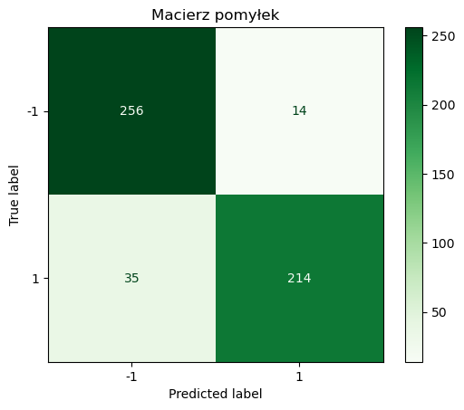

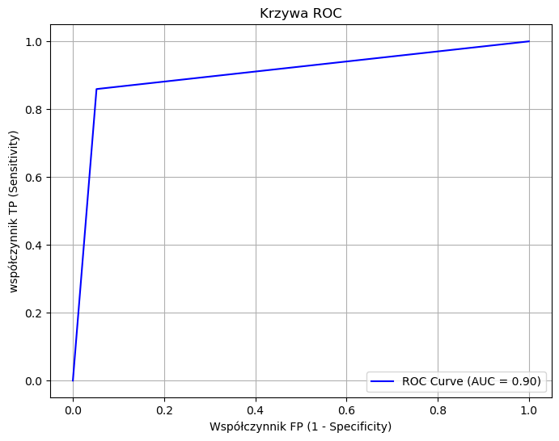

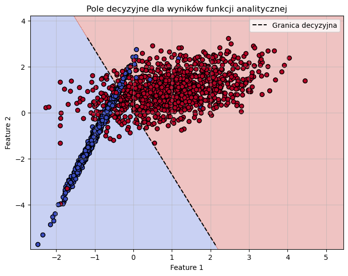

```
Czas wykonania metody sklearn: 0.49330592155456543s.
[[256  14]
 [ 35 214]]
Sklearn na Generate classifier:
Skuteczność: 90.5588%
Czułość (Recall): 85.9438%
Swoistość: 94.8148%
ROC AUC: 0.9038
```

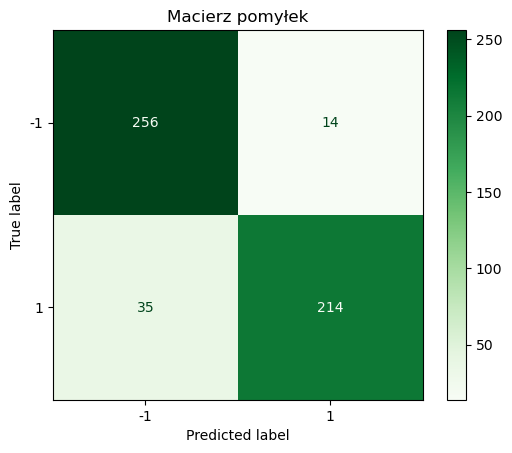

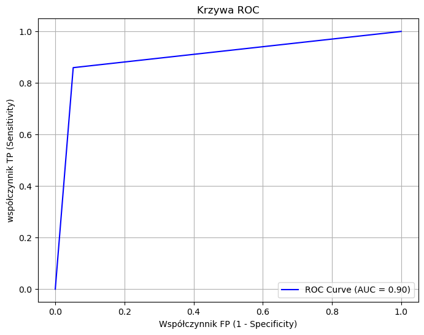

```python
X, y = generate_data(2595, 2, 95)
evaluate_dataset(X, y, "Generate classifier")
```

#### Zbiór *make_moons*:

```
Czas wykonania metody analitycznej: 0.03656172752380371s.
[[220  35]
 [ 24 240]]
Analityczna na Make moons:
Skuteczność: 88.6320%
Czułość (Recall): 90.9091%
Swoistość: 86.2745%
ROC AUC: 0.8859
```

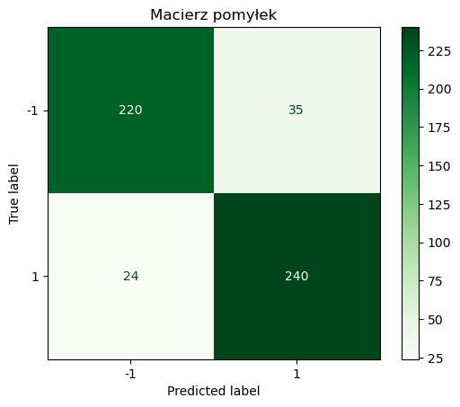

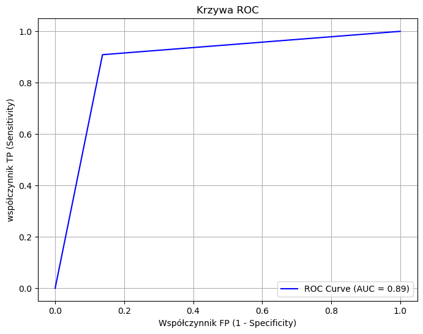

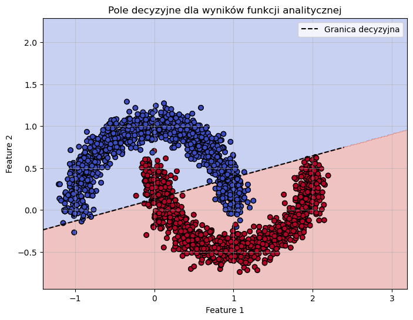

```
Czas wykonania metody sklearn: 0.46671628952026367s.
[[220  35]
 [ 24 240]]
Sklearn na Make moons:
Skuteczność: 88.6320%
Czułość (Recall): 90.9091%
Swoistość: 86.2745%
ROC AUC: 0.8859
```

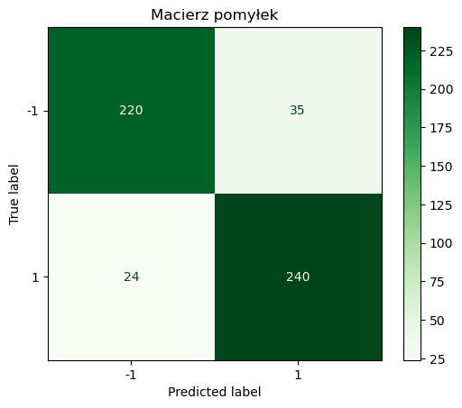

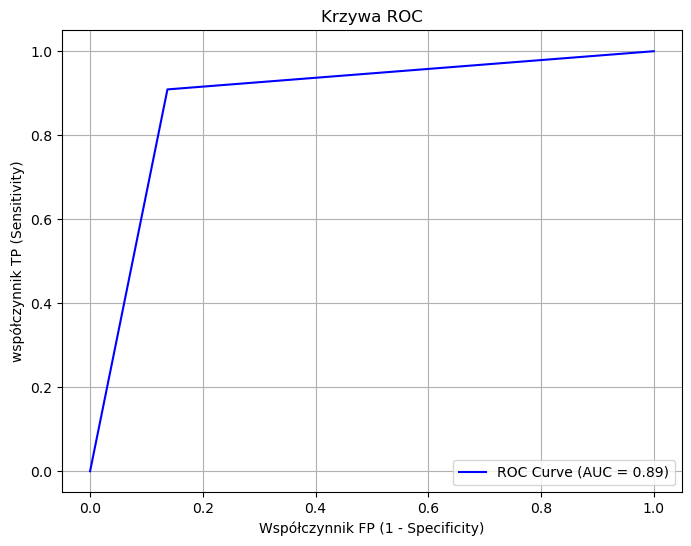

```python
X_moons, y_moons = generate_moons(2595, 95)
evaluate_dataset(X_moons, y_moons, "Make moons")
```

### Obserwacje i wnioski:

- Dla obu zbiorów skuteczność wychodzi na wysokim poziomie (**90%** oraz **89%**)
- Metoda analityczna jest znacznie szybsza od gotowej z biblioteki *sklearn*.

## 2.1 Eksploracja danych

### Zbiór danych zawiera następujące cechy:

Cechy zbioru danych:

1. age (ciągła): wiek w latach
2. sex (kategoryczna): płeć (1 = mężczyzna, 0 = kobieta)
3. cp (kategoryczna): typ bólu klatki piersiowej (1 = typowa angina, 2 = nietypowa angina, 3 = ból nieanginowy, 4 = bezobjawowy)
4. trestbps (ciągła): spoczynkowe ciśnienie krwi (mm Hg)
5. chol (ciągła): poziom cholesterolu w surowicy (mg/dl)
6. fbs (kategoryczna): poziom cukru we krwi na czczo > 120 mg/dl (1 = prawda, 0 = fałsz)
7. restecg (kategoryczna): wyniki spoczynkowego EKG (0 = normalne, 1 = anomalie ST-T, 2 = przerost lewej komory)
8. thalach (ciągła): maksymalne tętno osiągnięte
9. exang (kategoryczna): angina wywołana wysiłkiem (1 = tak, 0 = nie)
10. oldpeak (ciągła): depresja ST wywołana wysiłkiem w stosunku do spoczynku
11. slope (kategoryczna): nachylenie segmentu ST podczas szczytowego wysiłku (1 = wznoszące, 2 = płaskie, 3 = opadające)
12. ca (dyskretna): liczba głównych naczyń krwionośnych (0–3) zabarwionych fluoryzacją
13. thal (kategoryczna): wynik badania talasemicznego (3 = normalny, 6 = stała wada, 7 = odwracalna wada)

```python
import pandas as pd
import numpy as np
import matplotlib.pyplot as plt
import seaborn as sns
```

### Zaczytanie danych z *url* wraz z przekształceniem ich przy pomocy biblioteki *pandas*:

```python
url = 'https://archive.ics.uci.edu/ml/machine-learning-databases/heart-disease/processed.cleveland.data'
columns = ['age', 'sex', 'cp', 'trestbps', 'chol', 'fbs', 'restecg', 'thalach', 'exang', 'oldpeak', 'slope', 'ca', 'thal', 'num']
data = pd.read_csv(url, names=columns)
print(f"Zbiór danych zawiera {data.shape[0]} wierszy.")
data
```

```
Zbiór danych zawiera 303 wierszy.
```

|  | age | sex | cp | trestbps | chol | fbs | restecg | thalach | exang | oldpeak | slope | ca | thal | num |
| --- | --- | --- | --- | --- | --- | --- | --- | --- | --- | --- | --- | --- | --- | --- |
| 0 | 63.0 | 1.0 | 1.0 | 145.0 | 233.0 | 1.0 | 2.0 | 150.0 | 0.0 | 2.3 | 3.0 | 0.0 | 6.0 | 0 |
| 1 | 67.0 | 1.0 | 4.0 | 160.0 | 286.0 | 0.0 | 2.0 | 108.0 | 1.0 | 1.5 | 2.0 | 3.0 | 3.0 | 2 |
| 2 | 67.0 | 1.0 | 4.0 | 120.0 | 229.0 | 0.0 | 2.0 | 129.0 | 1.0 | 2.6 | 2.0 | 2.0 | 7.0 | 1 |
| 3 | 37.0 | 1.0 | 3.0 | 130.0 | 250.0 | 0.0 | 0.0 | 187.0 | 0.0 | 3.5 | 3.0 | 0.0 | 3.0 | 0 |
| 4 | 41.0 | 0.0 | 2.0 | 130.0 | 204.0 | 0.0 | 2.0 | 172.0 | 0.0 | 1.4 | 1.0 | 0.0 | 3.0 | 0 |
| ... | ... | ... | ... | ... | ... | ... | ... | ... | ... | ... | ... | ... | ... | ... |
| 298 | 45.0 | 1.0 | 1.0 | 110.0 | 264.0 | 0.0 | 0.0 | 132.0 | 0.0 | 1.2 | 2.0 | 0.0 | 7.0 | 1 |
| 299 | 68.0 | 1.0 | 4.0 | 144.0 | 193.0 | 1.0 | 0.0 | 141.0 | 0.0 | 3.4 | 2.0 | 2.0 | 7.0 | 2 |
| 300 | 57.0 | 1.0 | 4.0 | 130.0 | 131.0 | 0.0 | 0.0 | 115.0 | 1.0 | 1.2 | 2.0 | 1.0 | 7.0 | 3 |
| 301 | 57.0 | 0.0 | 2.0 | 130.0 | 236.0 | 0.0 | 2.0 | 174.0 | 0.0 | 0.0 | 2.0 | 1.0 | 3.0 | 1 |
| 302 | 38.0 | 1.0 | 3.0 | 138.0 | 175.0 | 0.0 | 0.0 | 173.0 | 0.0 | 0.0 | 1.0 | ? | 3.0 | 0 |

303 rows × 14 columns

### Brakujące wartości i ich usunięcie

- Na początku sprawdzamy, w których kolumnach zbiór danych posiada puste wartości (wartości *?*).
- Potem wypełniamy je wartością NaN.
- Na końcu, usuwamy te wiersze, które zawierają wartości NaN.

```python
print("Sprawdzenie w których kolumnach są puste wartości:")
print(data.isin(['?']).sum())

data = data.replace('?', np.nan)
data_clean = data.dropna()

print(f"\nLiczba wierszy po usunięciu brakujących wartości: {data_clean.shape[0]}")
```

```
Sprawdzenie w których kolumnach są puste wartości:
age         0
sex         0
cp          0
trestbps    0
chol        0
fbs         0
restecg     0
thalach     0
exang       0
oldpeak     0
slope       0
ca          4
thal        2
num         0
dtype: int64

Liczba wierszy po usunięciu brakujących wartości: 297
```

### Zamiana wartości przewidywanych na binarne wartości

Przekształcamy wartości stadium choroby (0-4) na binarne wartości:

- **0** - brak choroby.
- **1** - choroba serca.

```python
binary_classification = data_clean['num'].apply(lambda x: 1 if x > 0 else 0)
data_clean['num'] = binary_classification
print(data_clean['num'].value_counts())
data_clean
```

```
num
0    160
1    137
Name: count, dtype: int64
```

|  | age | sex | cp | trestbps | chol | fbs | restecg | thalach | exang | oldpeak | slope | ca | thal | num |
| --- | --- | --- | --- | --- | --- | --- | --- | --- | --- | --- | --- | --- | --- | --- |
| 0 | 63.0 | 1.0 | 1.0 | 145.0 | 233.0 | 1.0 | 2.0 | 150.0 | 0.0 | 2.3 | 3.0 | 0.0 | 6.0 | 0 |
| 1 | 67.0 | 1.0 | 4.0 | 160.0 | 286.0 | 0.0 | 2.0 | 108.0 | 1.0 | 1.5 | 2.0 | 3.0 | 3.0 | 1 |
| 2 | 67.0 | 1.0 | 4.0 | 120.0 | 229.0 | 0.0 | 2.0 | 129.0 | 1.0 | 2.6 | 2.0 | 2.0 | 7.0 | 1 |
| 3 | 37.0 | 1.0 | 3.0 | 130.0 | 250.0 | 0.0 | 0.0 | 187.0 | 0.0 | 3.5 | 3.0 | 0.0 | 3.0 | 0 |
| 4 | 41.0 | 0.0 | 2.0 | 130.0 | 204.0 | 0.0 | 2.0 | 172.0 | 0.0 | 1.4 | 1.0 | 0.0 | 3.0 | 0 |
| ... | ... | ... | ... | ... | ... | ... | ... | ... | ... | ... | ... | ... | ... | ... |
| 297 | 57.0 | 0.0 | 4.0 | 140.0 | 241.0 | 0.0 | 0.0 | 123.0 | 1.0 | 0.2 | 2.0 | 0.0 | 7.0 | 1 |
| 298 | 45.0 | 1.0 | 1.0 | 110.0 | 264.0 | 0.0 | 0.0 | 132.0 | 0.0 | 1.2 | 2.0 | 0.0 | 7.0 | 1 |
| 299 | 68.0 | 1.0 | 4.0 | 144.0 | 193.0 | 1.0 | 0.0 | 141.0 | 0.0 | 3.4 | 2.0 | 2.0 | 7.0 | 1 |
| 300 | 57.0 | 1.0 | 4.0 | 130.0 | 131.0 | 0.0 | 0.0 | 115.0 | 1.0 | 1.2 | 2.0 | 1.0 | 7.0 | 1 |
| 301 | 57.0 | 0.0 | 2.0 | 130.0 | 236.0 | 0.0 | 2.0 | 174.0 | 0.0 | 0.0 | 2.0 | 1.0 | 3.0 | 1 |

297 rows × 14 columns

### Opis podstawowych danych statystycznych.

#### Cechy ciągłe:

```
Statystyki dla cech ciągłych:
              age    trestbps        chol     thalach     oldpeak
count  297.000000  297.000000  297.000000  297.000000  297.000000
mean    54.542088  131.693603  247.350168  149.599327    1.055556
std      9.049736   17.762806   51.997583   22.941562    1.166123
min     29.000000   94.000000  126.000000   71.000000    0.000000
25%     48.000000  120.000000  211.000000  133.000000    0.000000
50%     56.000000  130.000000  243.000000  153.000000    0.800000
75%     61.000000  140.000000  276.000000  166.000000    1.600000
max     77.000000  200.000000  564.000000  202.000000    6.200000

Dominanta dla cech ciągłych:
age: 58.0
trestbps: 120.0
chol: 197.0
thalach: 162.0
oldpeak: 0.0
```

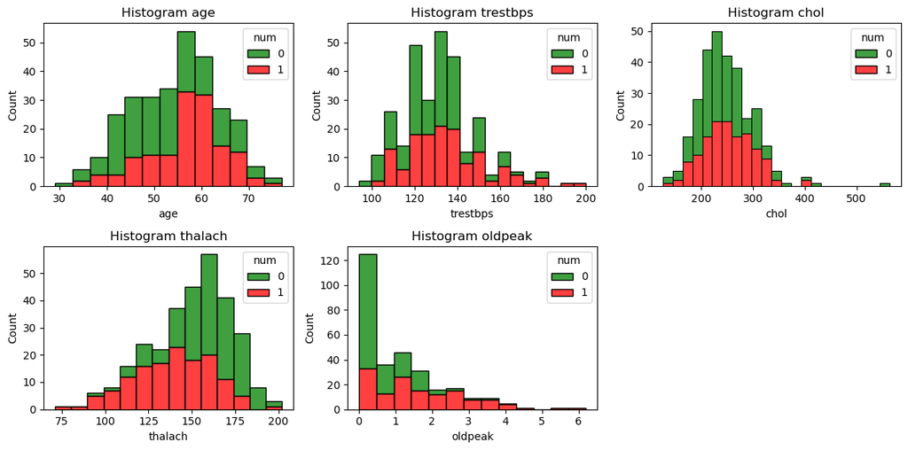

```python
continuous_features = ['age', 'trestbps', 'chol', 'thalach', 'oldpeak']

print("Statystyki dla cech ciągłych:")
continuous_stats = data_clean[continuous_features].describe()
print(continuous_stats)

print("\nDominanta dla cech ciągłych:")
for feature in continuous_features:
    mode = data_clean[feature].mode()[0]
    print(f"{feature}: {mode}")

plt.figure(figsize=(12, 6))
for i, feature in enumerate(continuous_features, 1):
    plt.subplot(2, 3, i)
    sns.histplot(data=data_clean, x=feature, hue='num', multiple='stack', palette={0: 'green', 1: 'red'})
    plt.title(f'Histogram {feature}')
plt.tight_layout()
plt.show()
```

#### Cechy kategoryczne:

```
Rozkład cech kategorycznych:
Cecha: sex:
sex
1.0    201
0.0     96
Name: count, dtype: int64
Cecha: cp:
cp
4.0    142
3.0     83
2.0     49
1.0     23
Name: count, dtype: int64
Cecha: fbs:
fbs
0.0    254
1.0     43
Name: count, dtype: int64
Cecha: restecg:
restecg
0.0    147
2.0    146
1.0      4
Name: count, dtype: int64
Cecha: exang:
exang
0.0    200
1.0     97
Name: count, dtype: int64
Cecha: slope:
slope
1.0    139
2.0    137
3.0     21
Name: count, dtype: int64
Cecha: thal:
thal
3.0    164
7.0    115
6.0     18
Name: count, dtype: int64
```

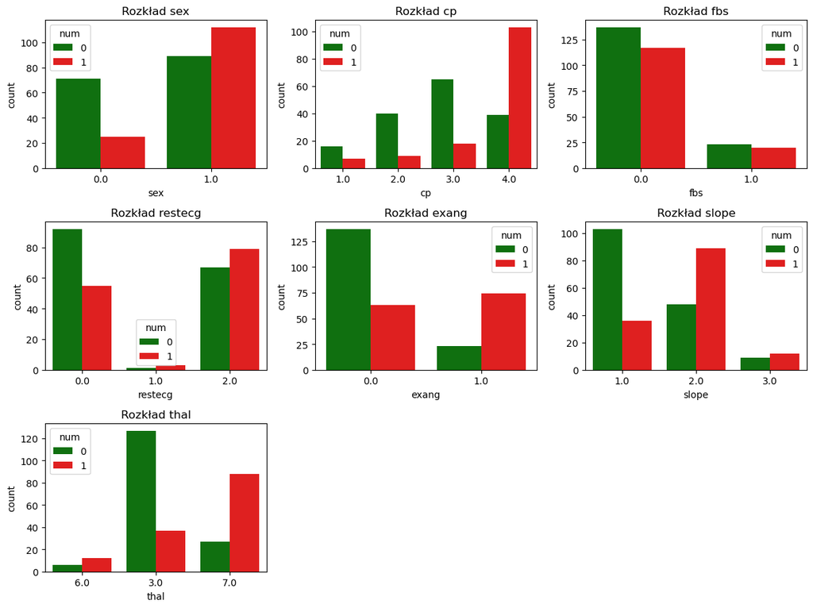

```python
categorical_features = ['sex', 'cp', 'fbs', 'restecg', 'exang', 'slope', 'thal']
print("Rozkład cech kategorycznych:")
for feature in categorical_features:
    print(f"Cecha: {feature}:")
    print(data_clean[feature].value_counts())

plt.figure(figsize=(12, 9))
for i, feature in enumerate(categorical_features, 1):
    plt.subplot(3, 3, i)
    sns.countplot(data=data_clean, x=feature, hue='num', palette={0: 'green', 1: 'red'})
    plt.title(f'Rozkład {feature}')
plt.tight_layout()
plt.show()
```

#### Cecha dyskretna:

```
Rozkład dla cechy dyskretnej (ca) - liczba zabarwionych naczyń krwionośnych fluoryzacją:
ca
0.0    174
1.0     65
2.0     38
3.0     20
Name: count, dtype: int64
```

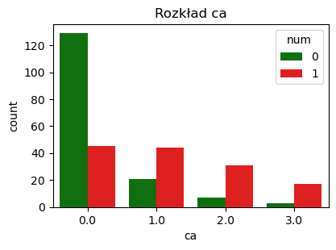

```python
print("Rozkład dla cechy dyskretnej (ca) - liczba zabarwionych naczyń krwionośnych fluoryzacją:")
print(data_clean['ca'].value_counts())

plt.figure(figsize=(15, 10))
plt.subplot(3, 3, i)
sns.countplot(data=data_clean, x=data_clean['ca'], hue='num', palette={0: 'green', 1: 'red'})
plt.title(f'Rozkład ca')
plt.show()
```

### Korelacja danych dla wszystkich cech:

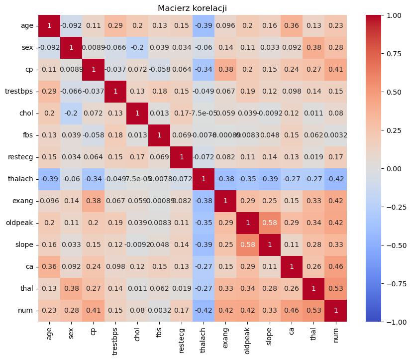

```python
plt.figure(figsize=(10, 8))
corr_matrix = data_clean.corr()
sns.heatmap(corr_matrix, annot=True, cmap='coolwarm', vmin=-1, vmax=1, center=0)
plt.title('Macierz korelacji')
```

### Wybór czterech cech:

Najlepszą korelację z wynikami choroby przedstawiają cechy:

- *ca* (0.46)
- *thal* (0.53)
- *oldpeak* (0.42)
- *exang* (0.42)
- *cp* (0.41)
- *thalach* (-0.42)

Przedstawmy więc zbliżoną macierz korelacji między powyższymi cechami:

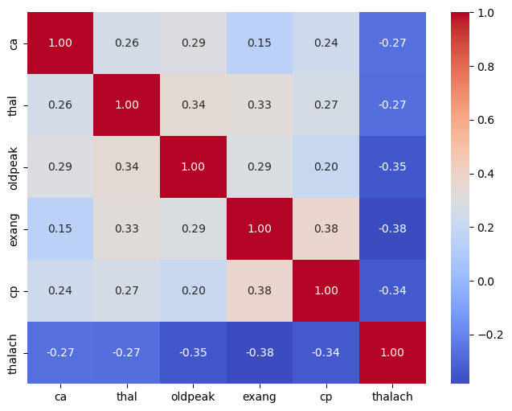

```python
features_to_check = ['ca', 'thal', 'oldpeak', 'exang', 'cp', 'thalach']
selected_correlation_matrix = corr_matrix.loc[features_to_check, features_to_check]
plt.figure(figsize=(8, 6))
sns.heatmap(selected_correlation_matrix, annot=True, fmt=".2f", cmap="coolwarm", cbar=True)
plt.show()
```

Żadne z cech nie wykazują wysokich powiązań między sobą, zatem **redundancja** nie zachodzi. Wybieramy 4 najważniejsze cechy, które miały wpływ na wynik decyzji czy choroba jest (najwyższa korelacja z wynikiem choroby)

## 2.3 Porównanie sklearn i własnej implementacji na zbiorze o chorobach serca i różnych zestawach cech

```python
from sklearn.preprocessing import MinMaxScaler
```

#### Normalizacja danych:

```python
data_clean = data_clean.apply(pd.to_numeric, errors='coerce')
y = data_clean.iloc[:, -1]
X = data_clean.drop(data_clean.columns[-1], axis=1)

scaler = MinMaxScaler(feature_range=(0, 1))
X_scaled = pd.DataFrame(
    scaler.fit_transform(X),
    columns=X.columns,
    index=X.index
)
print(X_scaled)
print(y)
```

```
          age  sex        cp  trestbps      chol  fbs  restecg   thalach  \
0    0.708333  1.0  0.000000  0.481132  0.244292  1.0      1.0  0.603053
1    0.791667  1.0  1.000000  0.622642  0.365297  0.0      1.0  0.282443
2    0.791667  1.0  1.000000  0.245283  0.235160  0.0      1.0  0.442748
3    0.166667  1.0  0.666667  0.339623  0.283105  0.0      0.0  0.885496
4    0.250000  0.0  0.333333  0.339623  0.178082  0.0      1.0  0.770992
..        ...  ...       ...       ...       ...  ...      ...       ...
297  0.583333  0.0  1.000000  0.433962  0.262557  0.0      0.0  0.396947
298  0.333333  1.0  0.000000  0.150943  0.315068  0.0      0.0  0.465649
299  0.812500  1.0  1.000000  0.471698  0.152968  1.0      0.0  0.534351
300  0.583333  1.0  1.000000  0.339623  0.011416  0.0      0.0  0.335878
301  0.583333  0.0  0.333333  0.339623  0.251142  0.0      1.0  0.786260

     exang   oldpeak  slope        ca  thal
0      0.0  0.370968    1.0  0.000000  0.75
```

[output cut: 24 more lines]

#### Implementacja własnej funkcji analitycznej oraz RidgeRegression z *sklearn*:

```python
def analytical_clf_fit(X, y, alpha=0.001):
    y = np.where(y == 0, -1, 1)
    y = np.array(y)
    X = np.array(X)

    X = np.hstack([X, np.ones((X.shape[0], 1))])
    n_samples, n_features = X.shape

    I = np.eye(n_features)
    I[-1, -1] = 0
    w = np.linalg.inv(X.T @ X + alpha * I) @ X.T @ y
    return w

def analytical_clf_predict(X, solution):
    bias = solution[-1]
    solution = solution[:-1]

    result = X @ solution + bias
    y_pred = (result > 0).astype(int)
    return y_pred

def sklearn_ridge_clf(X_train, y_train, X_test, alpha=0.001):
    clf = RidgeClassifier(alpha=alpha)

    clf.fit(X_train, y_train)
    predictions = clf.predict(X_test)

    return predictions
```

### Porównanie własnej implementacji z *sklearn* RidgeRegression dla **13 cech**:

```python
X_train, X_test, y_train, y_test = train_test_split(X_scaled, y, test_size=0.2, random_state=259195)

start = time.time()
for _ in range(100):
    w = analytical_clf_fit(X_train, y_train)
    predictions1 = analytical_clf_predict(X_test, w)
end = time.time()
print(f"Czas wykonania funkcji analitycznej: {end - start}s.")
compute_metrics(y_test, predictions1, "Analityczna", "Cleveland", [0, 1])

start = time.time()
for _ in range(100):
    predictions2 = sklearn_ridge_clf(X_train, y_train, X_test)
end = time.time()
print(f"Czas wykonania funkcji sklearn: {end - start}s.")
compute_metrics(y_test, predictions2, "Sklearn", "Cleveland", [0, 1])
```

[output not shown]

```
Czas wykonania funkcji analitycznej: 0.10314774513244629s.
[[31  1]
 [ 6 22]]
Analityczna na Cleveland:
Skuteczność: 88.3333%
Czułość (Recall): 78.5714%
Swoistość: 96.8750%
ROC AUC: 0.8772
```

```
Czas wykonania funkcji sklearn: 0.8207471370697021s.
[[31  1]
 [ 6 22]]
Sklearn na Cleveland:
Skuteczność: 88.3333%
Czułość (Recall): 78.5714%
Swoistość: 96.8750%
ROC AUC: 0.8772
```

### Porównanie RidgeRegression dla **4 cech**, wybranych automatycznie przy pomocy *sklearn* i własnych

#### Cechy wybierane automatycznie:

```python
from sklearn.feature_selection import SequentialFeatureSelector
from sklearn.linear_model import RidgeClassifier

rdg_clf = RidgeClassifier(alpha=0.001)
sfs = SequentialFeatureSelector(rdg_clf, n_features_to_select=4, direction='forward')
sfs.fit(X_scaled, y)

selected_features = X_scaled.columns[sfs.get_support()].tolist()
print(f"Wybrane cechy:, {selected_features}")
```

```
Wybrane cechy:, ['thalach', 'exang', 'ca', 'thal']
```

#### Test funkcji dla cech wybranych automatycznie:

```python
X_selected = X_scaled[selected_features]
print(X_selected)

X_train, X_test, y_train, y_test = train_test_split(X_selected, y, test_size=0.2, random_state=259195)

start = time.time()
for _ in range(100):
    w = analytical_clf_fit(X_train, y_train)
    predictions1 = analytical_clf_predict(X_test, w)
end = time.time()
print(f"Czas wykonania funkcji analitycznej: {end - start}s.")
compute_metrics(y_test, predictions1, "Analityczna", "Cleveland", [0, 1])

start = time.time()
for _ in range(100):
    predictions2 = sklearn_ridge_clf(X_train, y_train, X_test)
end = time.time()
print(f"Czas wykonania funkcji sklearn: {end - start}s.")
compute_metrics(y_test, predictions2, "Sklearn", "Cleveland", [0, 1])
```

[output not shown]

```
      thalach  exang        ca  thal
0    0.603053    0.0  0.000000  0.75
1    0.282443    1.0  1.000000  0.00
2    0.442748    1.0  0.666667  1.00
3    0.885496    0.0  0.000000  0.00
4    0.770992    0.0  0.000000  0.00
..        ...    ...       ...   ...
297  0.396947    1.0  0.000000  1.00
298  0.465649    0.0  0.000000  1.00
299  0.534351    0.0  0.666667  1.00
300  0.335878    1.0  0.333333  1.00
301  0.786260    0.0  0.333333  0.00

[297 rows x 4 columns]
Czas wykonania funkcji analitycznej: 0.0930628776550293s.
[[31  1]
 [ 6 22]]
Analityczna na Cleveland:
Skuteczność: 88.3333%
Czułość (Recall): 78.5714%
Swoistość: 96.8750%
ROC AUC: 0.8772
```

```
Czas wykonania funkcji sklearn: 0.7382924556732178s.
[[31  1]
 [ 6 22]]
Sklearn na Cleveland:
Skuteczność: 88.3333%
Czułość (Recall): 78.5714%
Swoistość: 96.8750%
ROC AUC: 0.8772
```

#### Test dla cech wybranych ręcznie:

```
           ca  thal   thalach   oldpeak
0    0.000000  0.75  0.603053  0.370968
1    1.000000  0.00  0.282443  0.241935
2    0.666667  1.00  0.442748  0.419355
3    0.000000  0.00  0.885496  0.564516
4    0.000000  0.00  0.770992  0.225806
..        ...   ...       ...       ...
297  0.000000  1.00  0.396947  0.032258
298  0.000000  1.00  0.465649  0.193548
299  0.666667  1.00  0.534351  0.548387
300  0.333333  1.00  0.335878  0.193548
301  0.333333  0.00  0.786260  0.000000

[297 rows x 4 columns]
Czas wykonania funkcji analitycznej: 0.09205460548400879s.
[[29  3]
 [ 8 20]]
Analityczna na Cleveland:
Skuteczność: 81.6667%
Czułość (Recall): 71.4286%
Swoistość: 90.6250%
ROC AUC: 0.8103
```

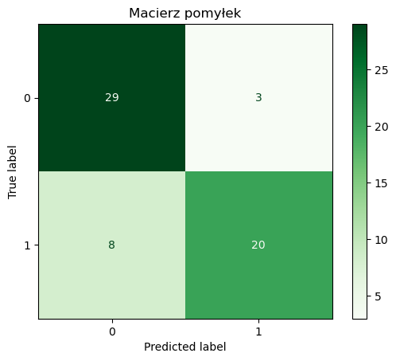

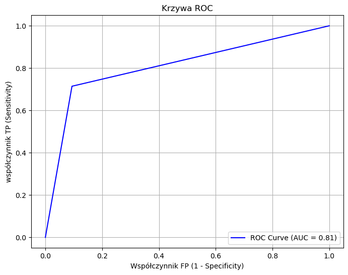

```
Czas wykonania funkcji sklearn: 0.6884291172027588s.
[[29  3]
 [ 8 20]]
Sklearn na Cleveland:
Skuteczność: 81.6667%
Czułość (Recall): 71.4286%
Swoistość: 90.6250%
ROC AUC: 0.8103
```

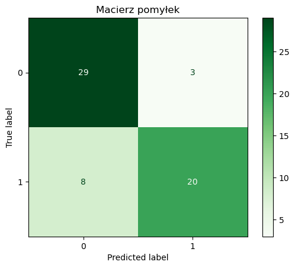

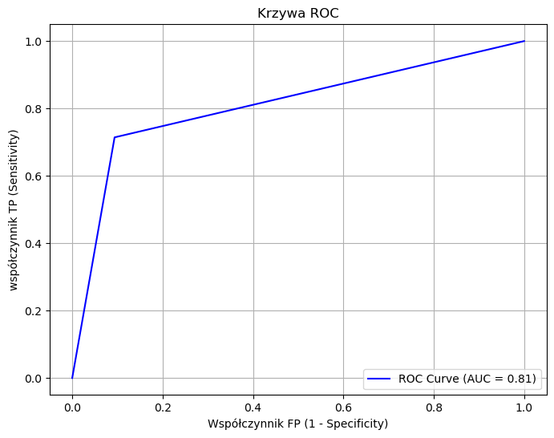

```python
own_features = ['ca', 'thal', 'thalach', 'oldpeak']
X_own = X_scaled[own_features]
print(X_own)

X_train, X_test, y_train, y_test = train_test_split(X_own, y, test_size=0.2, random_state=259195)

start = time.time()
for _ in range(100):
    w = analytical_clf_fit(X_train, y_train)
    predictions1 = analytical_clf_predict(X_test, w)
end = time.time()
print(f"Czas wykonania funkcji analitycznej: {end - start}s.")
compute_metrics(y_test, predictions1, "Analityczna", "Cleveland", [0, 1])

start = time.time()
for _ in range(100):
    predictions2 = sklearn_ridge_clf(X_train, y_train, X_test)
end = time.time()
print(f"Czas wykonania funkcji sklearn: {end - start}s.")
compute_metrics(y_test, predictions2, "Sklearn", "Cleveland", [0, 1])
```